# Продвинутые темы - третий этап внешнего курса

Презентация

Виноградова М. А.

Российский университет дружбы народов, Москва, Россия

16 мая 2025

# Информация

## Докладчик

- Виноградова Мария Андреевна
- Студентка (студ. билет 1132240691)
- группа НПИбд-01-24
- Российский университет дружбы народов
- 1132240691@pfur.ru
- https://github.com/mavinogradova/study_2024-2025_os-intro

# Цель работы

Рассмотреть несколько продвинутых тем, включающих в себя основы написания скриптов на языке bash, использовать многофункционального текстового редактора vim и другие.

# Выполнение третьего этапа внешнего курса

## Ознакамливаемся с первым вопросом

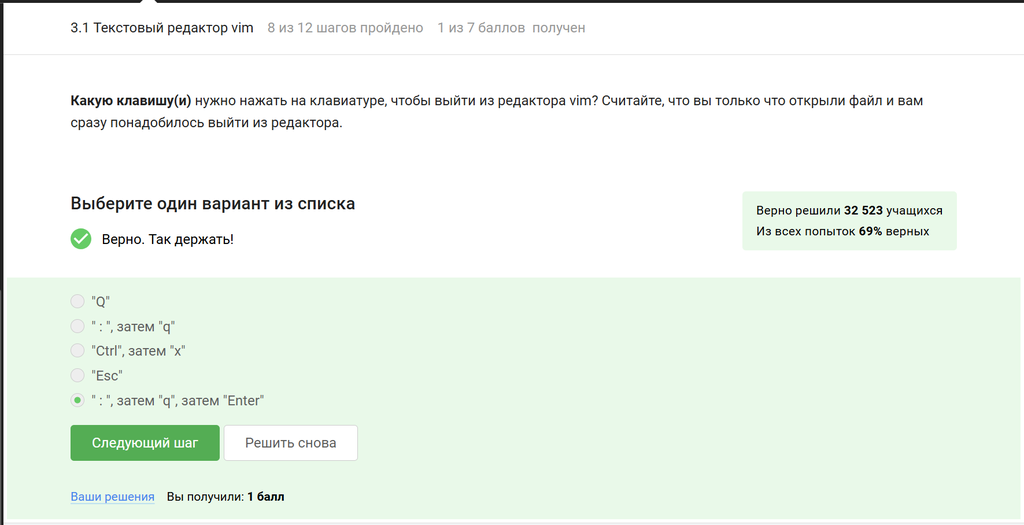

Смотрим текст вопроса

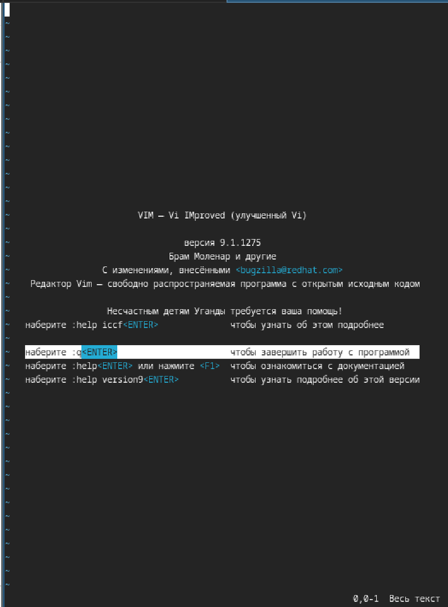

Изучаем краткую справку программы

## Ознакамливаемся со вторым вопросом

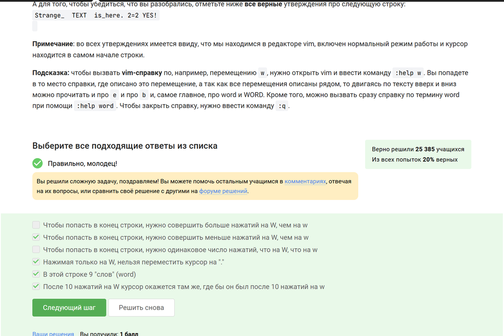

Смотрим текст вопроса

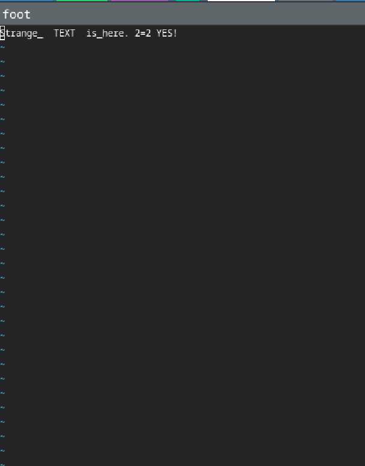

Практически проверяем каждый ответ

## Ознакамливаемся с третьим вопросом

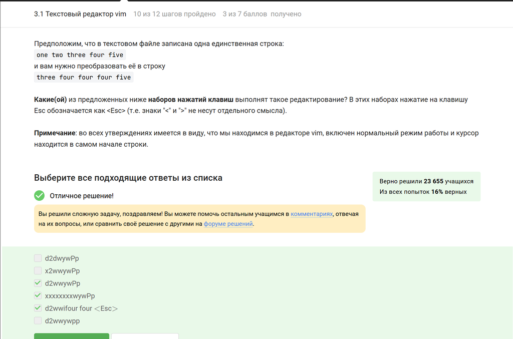

Смотрим текст вопроса

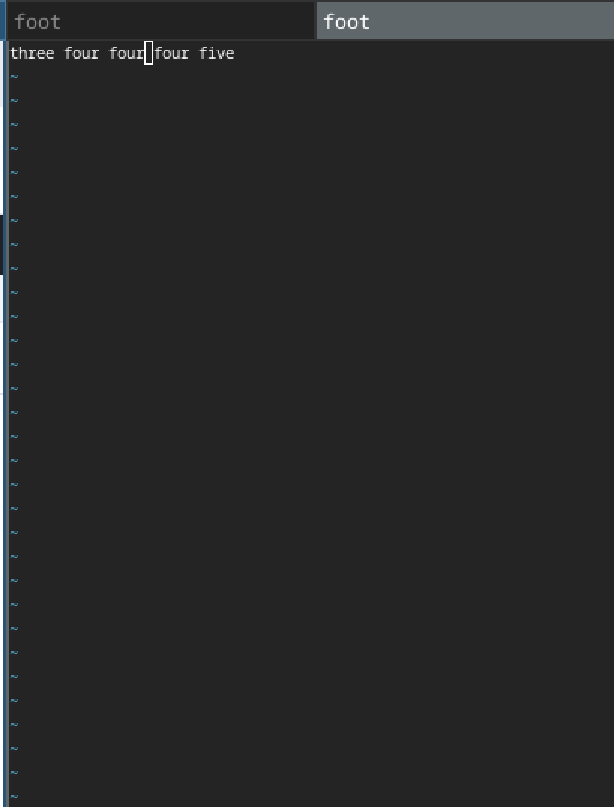

Практически проверяем каждый ответ

## Ознакамливаемся с четвертым вопросом

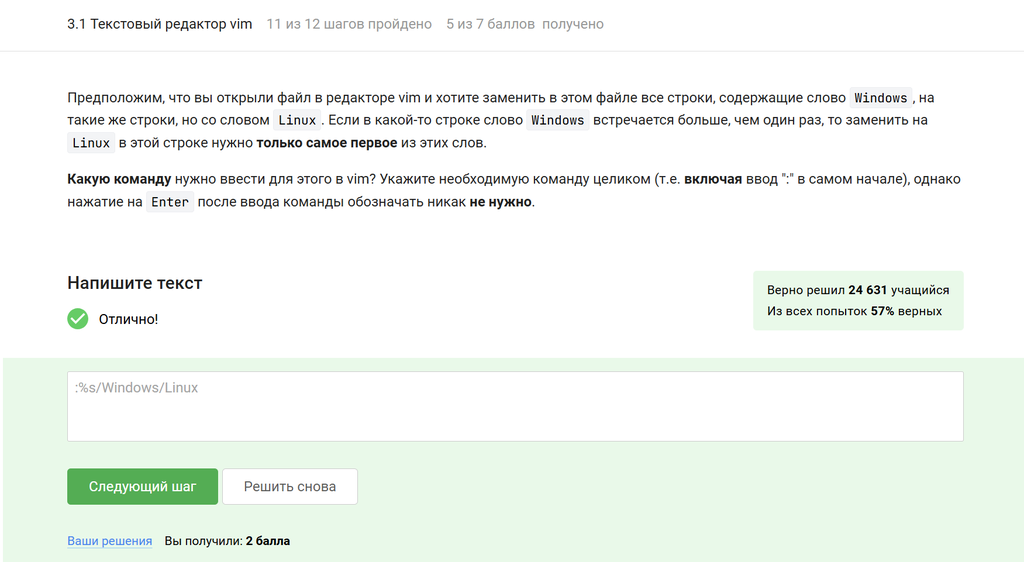

Смотрим текст вопроса

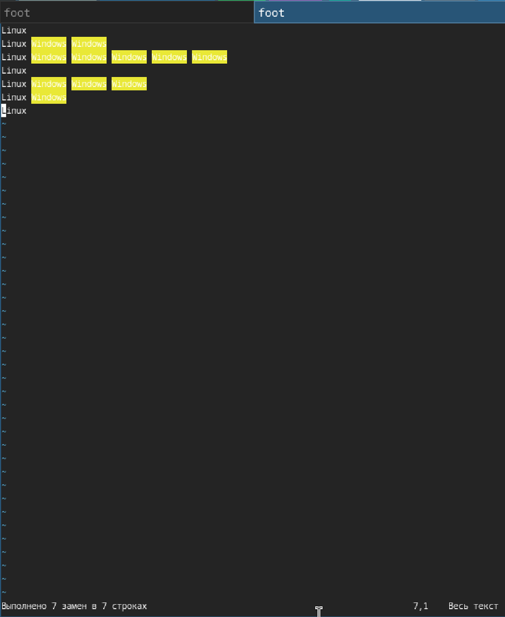

Пишем команду

## Ознакамливаемся с пятым вопросом

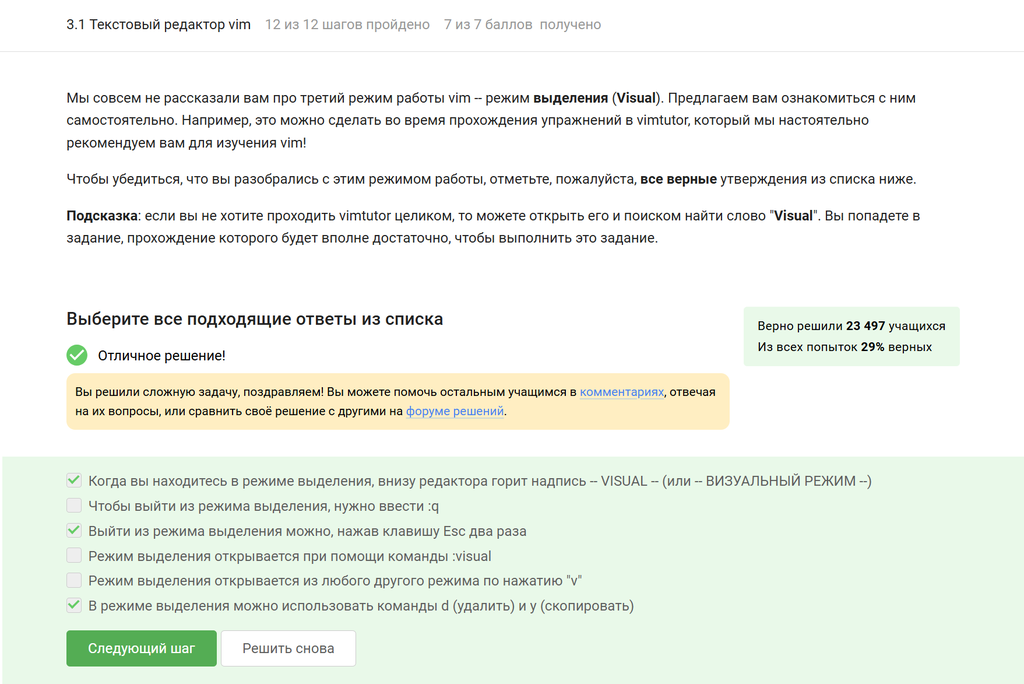

Смотрим текст вопроса

## Почему ответ верен:

- VISUAL отображается внизу При активации режима Visual (клавиша v) в строке состояния Vim появляется надпись VISUAL, что помогает пользователю понять текущий режим. Это стандартное поведение Vim, аналогичное INSERT для режима вставки.
- Выход по двойному Esc В Vim одиночное нажатие Esc всегда возвращает в нормальный режим (Normal mode). Если Esc не срабатывает (редкие случаи, например, при зависании плагина), второе нажатие гарантирует выход.
- Команды d (удалить) и y (копировать) работают В режиме Visual выделенный текст можно: Удалить (d или x). Скопировать (y). Изменить (c).

(ранее мы могли это наблюдать на практике)

## Ознакамливаемся с шестым вопросом

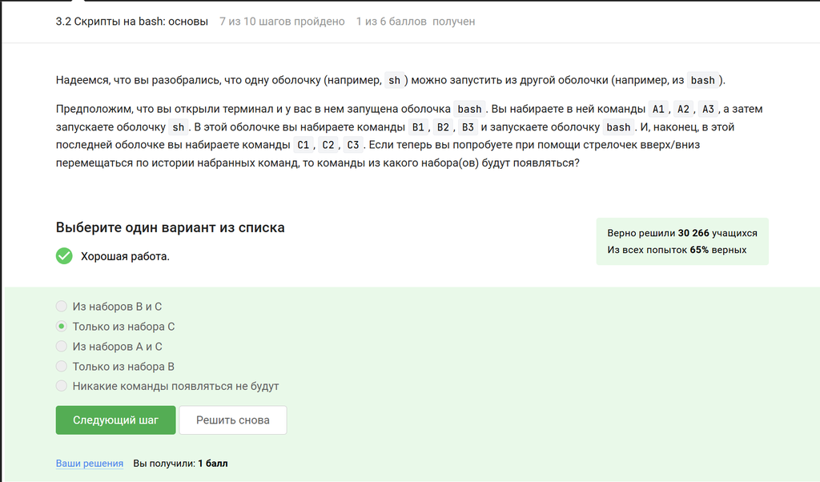

Смотрим текст вопроса

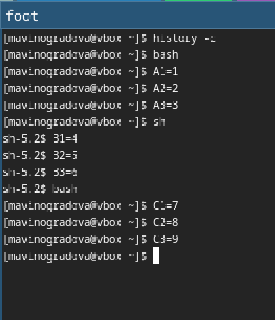

Проверяем историю команд поссле запуска 3 команд

## Ознакамливаемся с седьмым вопросом

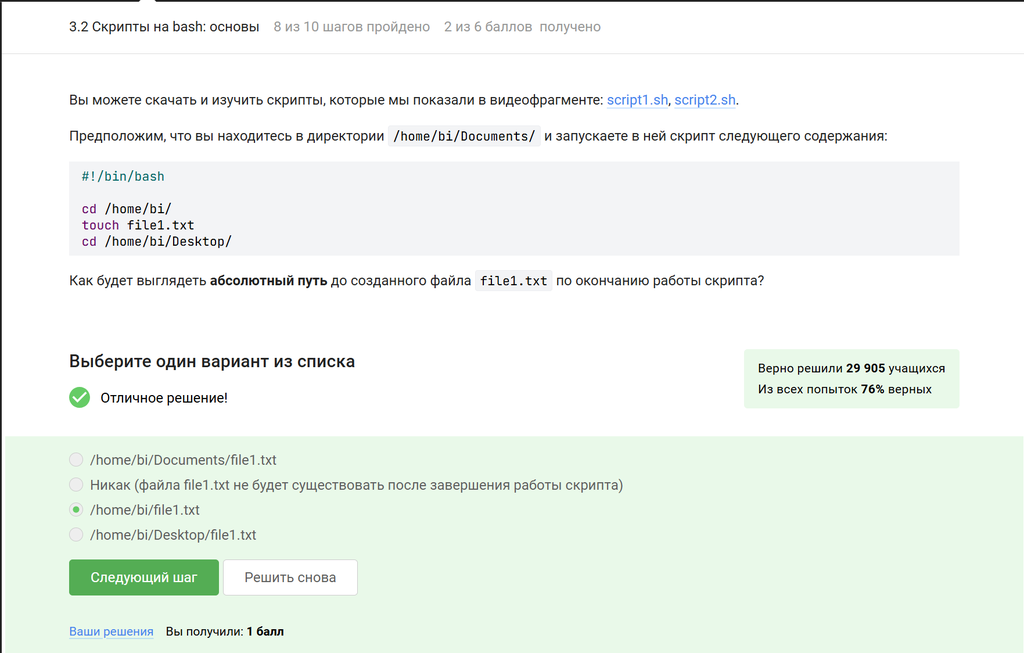

Смотрим текст вопроса

## Почему ответ верен: Заходим в дирректорию создаем через терминал файл и затем переходим в другую деррикторию, после чего проверяем местонахождение файла

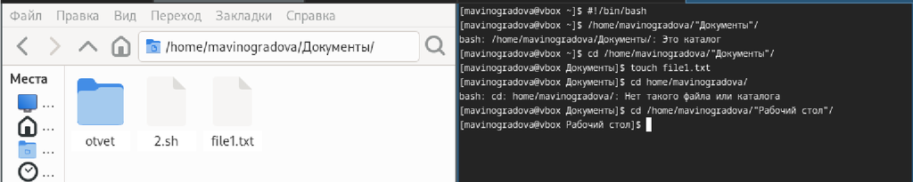

## Ознакамливаемся с восьмым вопросом

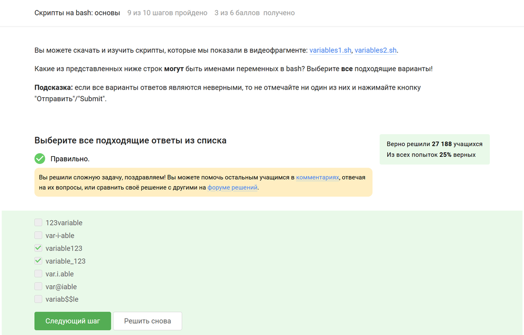

Смотрим текст вопроса

## Почему ответ верен: Создаем файл и записываем туда все варианты ответа, после чего смотрим на вывод программы (если выдает ошибку значит ответ не верен)

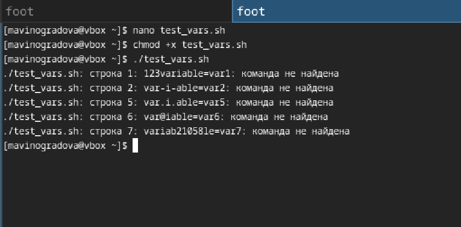

Смотрим на вывод программы

## Ознакамливаемся с девятым вопросом

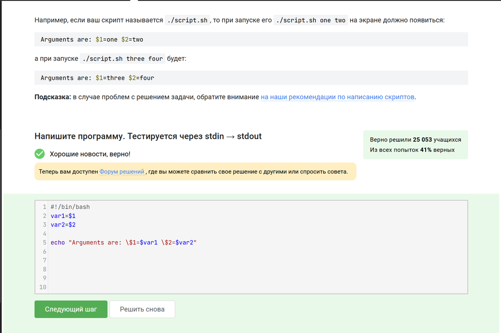

Смотрим текст вопроса

## Почему ответ верен: Пишем скрипт на bash

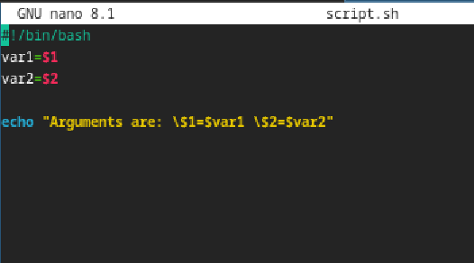

Пишем программу

## Смотрим вывод, после чего изменяем что-то в программе если вывод не соответствует приведенному примеру

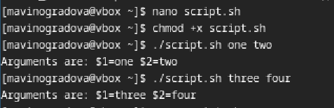

Сверяем вывод и пример

## Ознакамливаемся с десятым вопросом

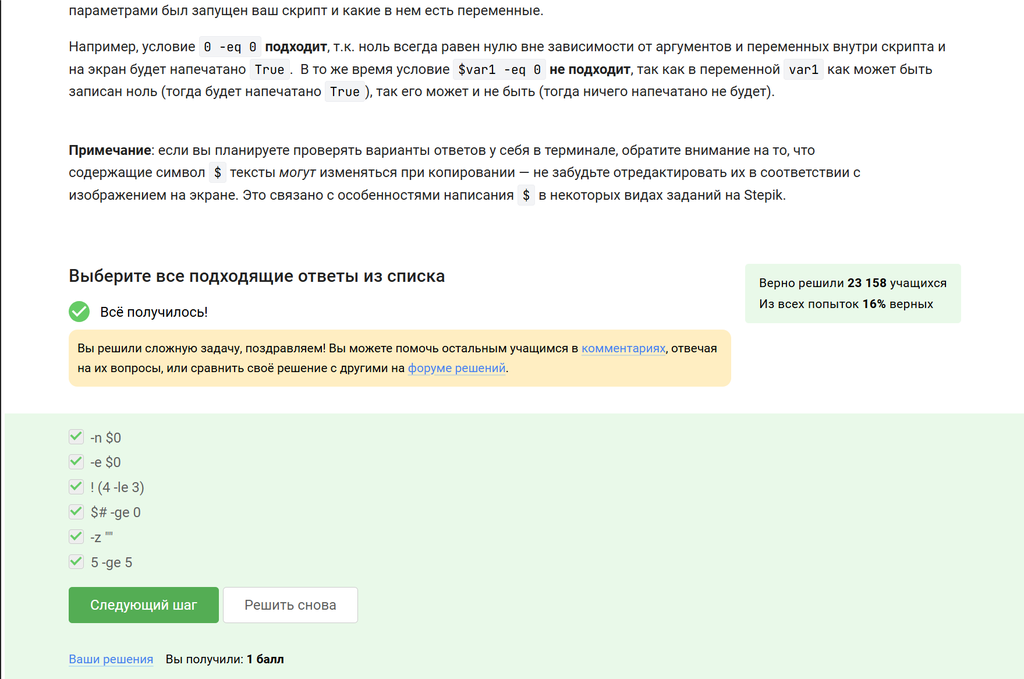

Смотрим текст вопроса

## Почему ответ верен: Пишем скрипт на bash и вносим туда все варианты ответа

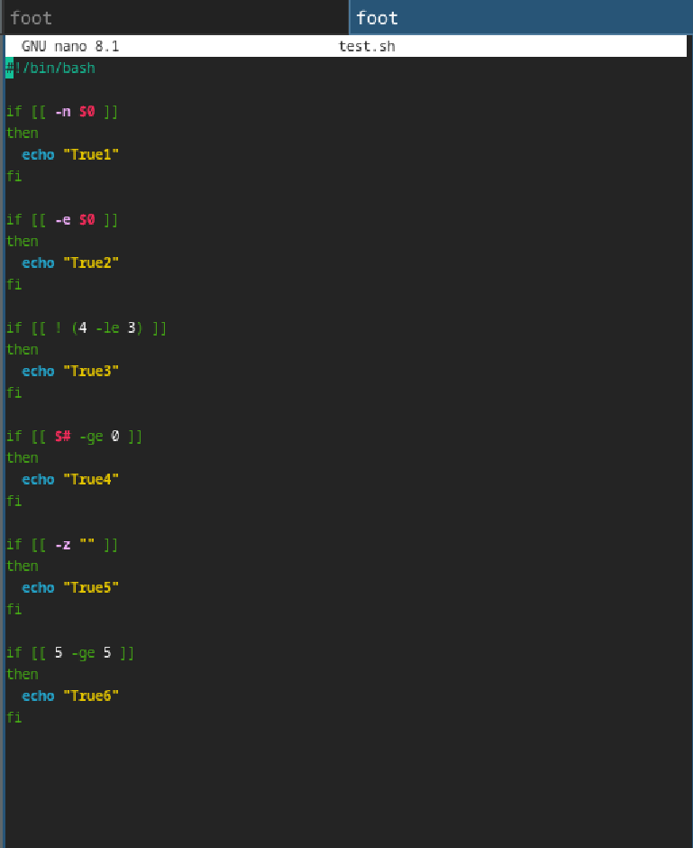

Пишем программу

## Смотрим вывод, если он верен то отмечаем правильный ответ

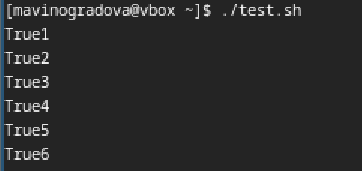

Смотрим вывод

## Ознакамливаемся с одиннадцатым вопросом

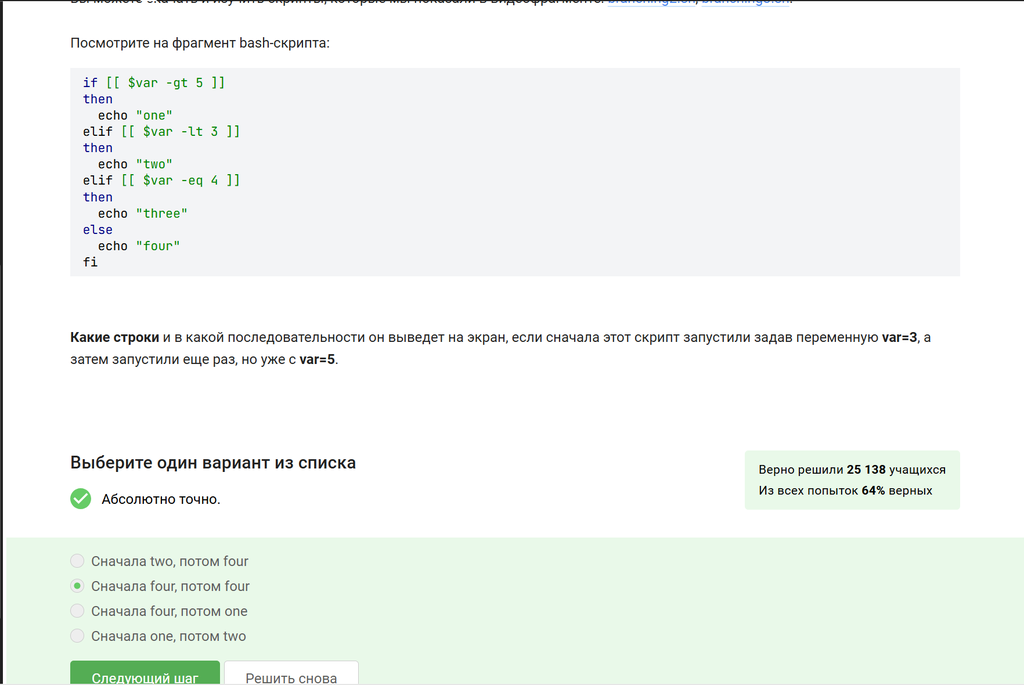

Смотрим текст вопроса

## Почему ответ верен:

Потому что такая логика программы

## Ознакамливаемся с двенадцатым вопросом

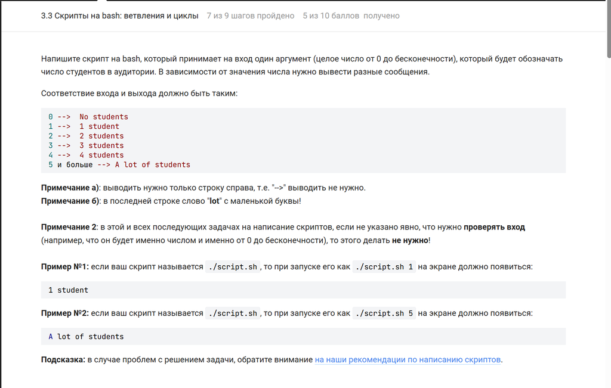

Смотрим текст вопроса

## Почему ответ верен: Пишем скрипт на bash

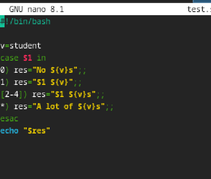

Пишем программу

## Смотрим вывод, после чего изменяем что-то в программе если вывод не соответствует приведенному примеру

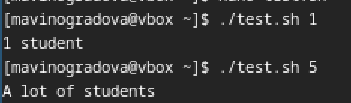

Сверяем вывод и пример

## Ознакамливаемся с тринадцатым вопросом

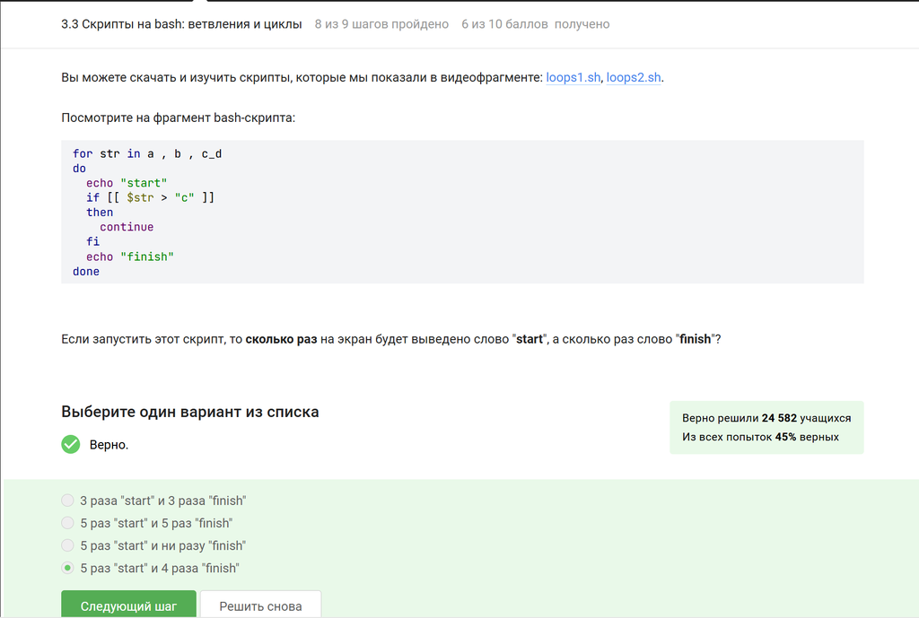

Смотрим текст вопроса

## Почему ответ верен:

- Цикл перебирает элементы a , b , c_d (5 элементов из-за запятых и пробелов).
- Условие if [ $str > “c” ] ложно для a, b, (пробел), , → вывод finish. Для c_d — истина (continue пропускает finish).

## Ознакамливаемся с четырнадцатым вопросом

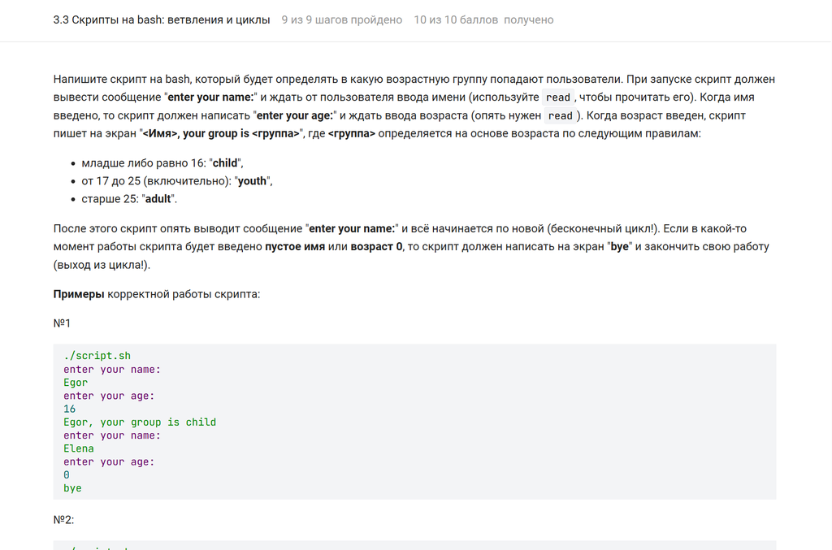

Смотрим текст вопроса

## Почему ответ верен: Пишем скрипт на bash

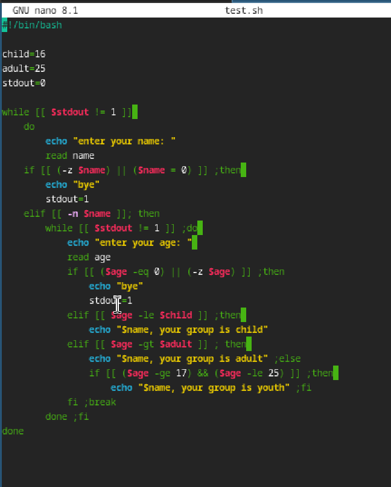

Пишем программу

## Смотрим вывод, после чего изменяем что-то в программе если вывод не соответствует приведенному примеру

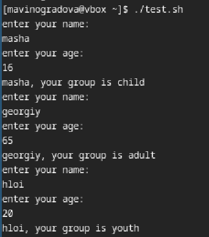

Сверяем вывод и пример

## Ознакамливаемся с пятнадцатым вопросом

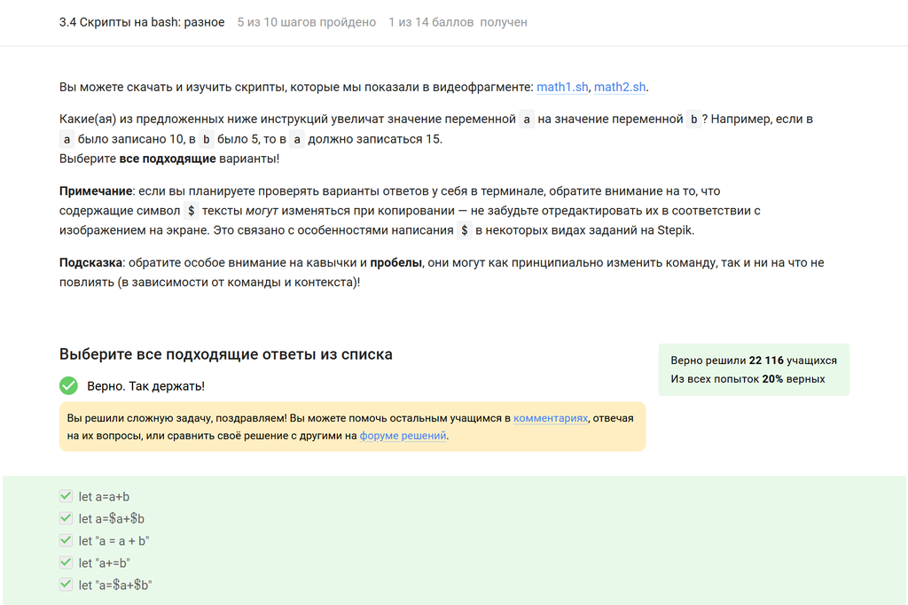

Смотрим текст вопроса

## Почему ответ верен: Пишем скрипт на bash и вносим туда все варианты ответа

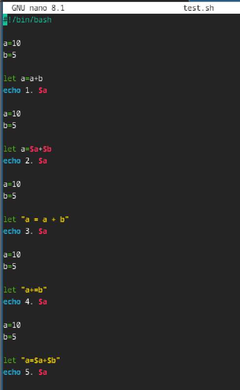

Пишем программу